# Análisis exploratorio

### 4.9 ¿Es posible que la cantidad de hombres y mujeres en el reparto influya en la popularidad y los ingresos de las películas?

Primero obtendremos la relacion entre hombres e ingresos.

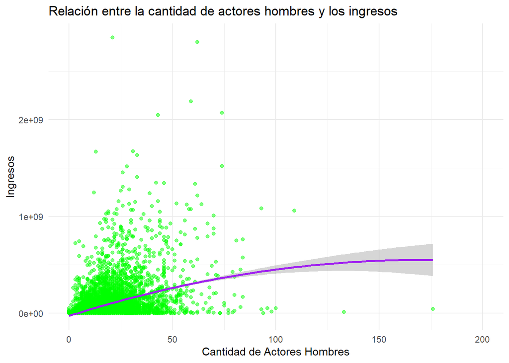

```r
ggplot(movies, aes(x = as.numeric(castMenAmount), y = revenue)) +
  geom_point(alpha = 0.5, color = "green") +
  geom_smooth(method = "lm", formula = y ~ poly(x, 2), color = "purple") +
  labs(title = "Relación entre la cantidad de actores hombres y los ingresos",
       x = "Cantidad de Actores Hombres",
       y = "Ingresos") +
  scale_x_continuous(limits = c(0, 200)) +
  theme_minimal()
```

##### Grafica de Dispersion Cantidad Hombres vs Ingresos , 200 datos posibles

Si no lo acotamos en el eje x nos daria

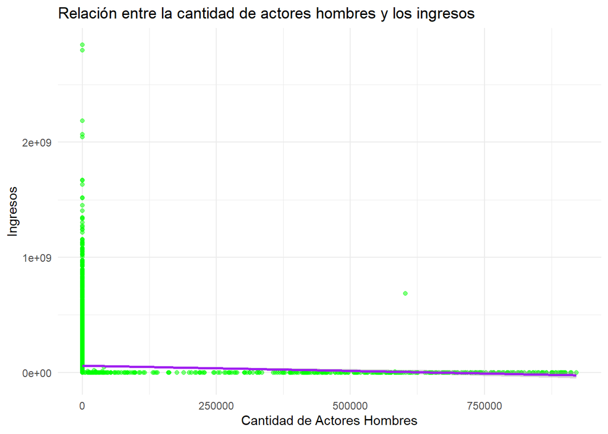

```r
echo=FALSE
ggplot(movies, aes(x = as.numeric(castMenAmount), y = revenue)) +
  geom_point(alpha = 0.5, color = "green") +
  geom_smooth(method = "lm", color = "purple") +
  labs(title = "Relación entre la cantidad de actores hombres y los ingresos",
       x = "Cantidad de Actores Hombres",
       y = "Ingresos")+
  theme_minimal()
```

Ahora obtendremos la relacion de mujeres

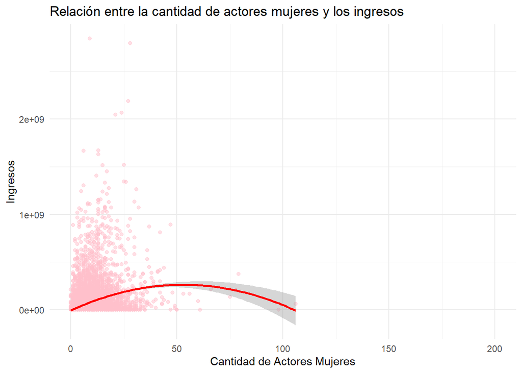

```r
ggplot(movies, aes(x = as.numeric(castWomenAmount), y = revenue)) +
  geom_point(alpha = 0.5, color = "pink") +
  geom_smooth(method = "lm",  formula = y ~ poly(x, 2), color = "red") +
  labs(title = "Relación entre la cantidad de actores mujeres y los ingresos",
       x = "Cantidad de Actores Mujeres",
       y = "Ingresos") +
  scale_x_continuous(limits = c(0, 200))+
  theme_minimal()
```

Si no lo acotamos en el eje x nos daria

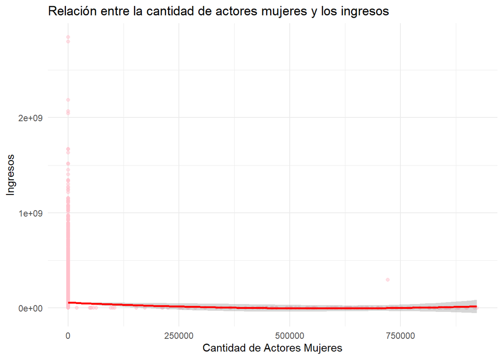

```r
ggplot(movies, aes(x = as.numeric(castWomenAmount), y = revenue)) +
  geom_point(alpha = 0.5, color = "pink") +
  geom_smooth(method = "lm",  formula = y ~ poly(x, 2), color = "red") +
  labs(title = "Relación entre la cantidad de actores mujeres y los ingresos",
       x = "Cantidad de Actores Mujeres",
       y = "Ingresos")+
  theme_minimal()
```

#### Analisis Grafico

Como se puede observar en la primera grafica tiende a existir mas ingresos mientras mas mujeres existan , sin embargo al igual que con la de los hombres esta suele decaer en cierto punto maximo hasta alcanzar a llegar a minimos de ingresos como se ve en la segunda grafica.

Ahora analizaremos su popularidad

#### Popularidad Hombres

[figure not shown]

```r
ggplot(movies, aes(x = as.numeric(castMenAmount), y = popularity)) +
  geom_point(alpha = 0.5, color = "green") +
  geom_smooth(method = "lm",formula = y ~ poly(x, 6), color = "red") +
  labs(title = "Relación entre la cantidad de actores hombres y los ingresos",
       x = "Cantidad de Actores Hombres",
       y = "Popularidad")+
  scale_x_continuous(limits = c(0, 200))+
  theme_minimal()
```

#### Popularidad Mujeres

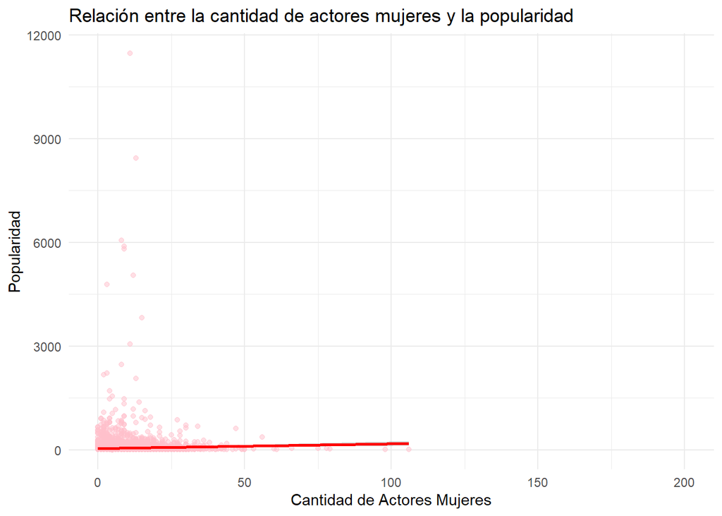

```r
ggplot(movies, aes(x = as.numeric(castWomenAmount), y = popularity)) +
  geom_point(alpha = 0.5, color = "pink") +
  geom_smooth(method = "lm", color = "red") +
  labs(title = "Relación entre la cantidad de actores mujeres y la popularidad",
       x = "Cantidad de Actores Mujeres",
       y = "Popularidad") +
     scale_x_continuous(limits = c(0, 200)) +  # Limitar el rango en el eje X
  theme_minimal()
```

#### Analisis Grafico

Como se puede observar en los hombres suele existir una distribucion de hombres con mayor popularidad en las peliculas que participan. En cambio en las mujeres las peliculas en las que menor cantidad de actrices suelen ser las que tienen mayor popularidad.

### 4.10 ¿Quiénes son los directores que hicieron las 20 películas mejor calificadas?

```r
library(knitr)
movies <- read.csv("movies.csv", stringsAsFactors = FALSE)
movies[] <- lapply(movies, function(x) iconv(x, from = "latin1", to = "UTF-8", sub = "byte"))

movies <- movies %>%
  mutate(voteAvg = as.numeric(voteAvg))  # Convertir voteAVG a numero

top_20_movies <- movies %>%
  filter(director != "") %>%
  arrange(desc(voteAvg)) %>%
  select(title, director, voteAvg) %>%
  head(20)
knitr::kable(top_20_movies, format = "html")
```

| title | director | voteAvg |
| --- | --- | --- |
| Hot Naked Sex & the City | Thomas Coven | 10.0 |
| Holidays | Víctor Barba\|Juan Olivares | 10.0 |
| Steven Universe: The Movie: Behind the Curtain | Rebecca Sugar | 10.0 |
| Spirit of Vengeance: The Making of ‘Ghost Rider’ | Laurent Bouzereau | 10.0 |
| How Ponyo was Born ~Hayao Miyazaki’s Thought Process~ | Kaku Arakawa | 10.0 |
| Christmas at the Ranch | Christin Baker | 10.0 |
| Los Vengadores Chiflados | Miguel Angel Zavala | 10.0 |
| The Spectacular Spider-Man Attack of the Lizard | Dave Bullock\|Troy Adomitis\|Victor Cook | 9.6 |
| Ebola Zombies | Samuel Leong | 9.5 |
| Aunt’s Temptation 3 | Won Myeong-jun | 9.5 |
| Live: The Last Concert | Selena Quintanilla | 9.4 |
| Demon Slayer: Kimetsu no Yaiba the Hashira Meeting Arc | Haruo Sotozaki | 9.3 |
| Demon Slayer: Kimetsu no Yaiba Sibling’s Bond | Haruo Sotozaki | 9.3 |
| Franco Escamilla: Por La Anécdota | Ulises Valencia | 9.2 |
| BTS World Tour: Love Yourself - Japan Edition | Kim Nam-joon\|Jeon Jung-kook\|Kim Tae-hyung\|Park Ji-min\|Jung Ho-seok\|Kim Seok-jin\|Min Yoon-gi | 9.2 |
| Break the Silence: The Movie | Park Jun-soo | 9.2 |
| Mission «Sky» | Igor Kopylov | 9.2 |
| Bring the Soul: The Movie | Park Jun-soo | 9.1 |
| Scooby-Doo! and the Spooky Scarecrow | Michael Goguen | 9.0 |
| Three Preludes for Solo Piano By Adam Sherkin | Filip Ghiorghi | 9.0 |

#### Conclusiones

Se puede observar que los 20 directores con las peliculas mejor calificadas suelen ser de un rango de 9.0 a 10 de nota dada por la critica. Lo cual es un buen indicativo de la capacidad de los directores de poder conseguir buena critica.

### 4.11 ¿Cómo se correlacionan los presupuestos con los ingresos?

Para ello haremos una grafica de correlacion

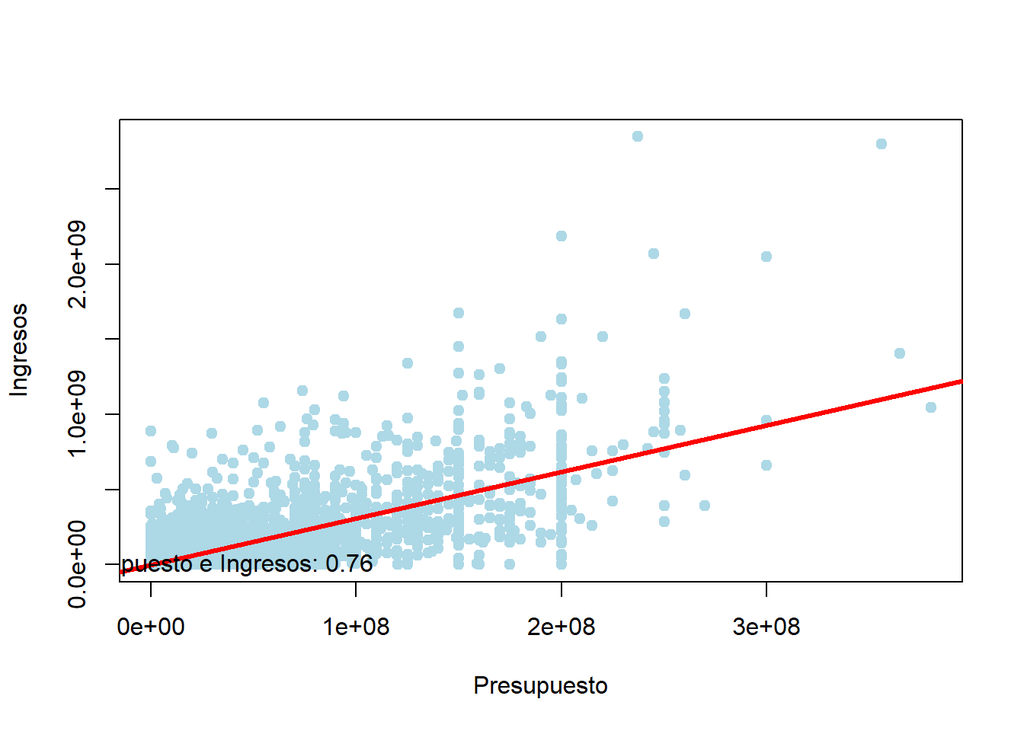

```r
movies <- read.csv("movies.csv", stringsAsFactors = FALSE)
movies$budget <- as.numeric(movies$budget)
movies$revenue <- as.numeric(movies$revenue)

x <- movies$budget
y <-movies$revenue

# Creamos el gráfico
plot(x, y, pch = 19, col = "lightblue",
     xlab = "Presupuesto",  # Título del eje X
     ylab = "Ingresos")

# Línea de regresión
abline(lm(y ~ x), col = "red", lwd = 3)


text(paste("Correlación Presupuesto e Ingresos:", round(cor(x, y), 2)), x = 25, y = 95)
```

#### Conclusiones

Como se puede observar en el gráfico de dispersión si hay una relación que tiende a un mayor presupuesto una mayor recaudación. Esto se debe a que una parte de los presupuestos se suele destinar a la publicidad lo que puede influir en su crecimiento. Sin embargo podemos observar ciertos puntos atípicos por encima y debajo de la linea de tendencia que muestran que muchas veces con menor presupuesto se logran una gran cantidad de ingresos y con mucho presupuesto suelen tener ingresos muy bajos. Aun asi la correlacion es muy alta siendo de 0.76 lo que indica que hay una correlacion entre ambas variables.

### 4.12 ¿Se asocian ciertos meses de lanzamiento con mejores ingresos?

Para ello agruparemos los meses y calcularemos el total de ingresos

```r
movies <- read.csv("movies.csv", stringsAsFactors = FALSE)
movies$releaseMonth <- as.numeric(substr(movies$releaseDate, 6, 7))


monthly_revenue <- movies %>%
  group_by(releaseMonth) %>%
  summarise(total_revenue = sum(revenue, na.rm = TRUE),
            avg_revenue = mean(revenue, na.rm = TRUE))%>%
  select(releaseMonth,total_revenue,avg_revenue)%>%
  arrange(desc(avg_revenue))




knitr::kable(monthly_revenue, format = "html")
```

| releaseMonth | total_revenue | avg_revenue |
| --- | --- | --- |
| 6 | 77597881637 | 94747108 |
| 5 | 61316118519 | 87845442 |
| 7 | 61735301475 | 76028696 |
| 12 | 69525553232 | 74358880 |
| 11 | 57694134749 | 71492112 |
| 4 | 36606574887 | 52595654 |
| 3 | 41659492701 | 51115942 |
| 2 | 30293297435 | 42908353 |
| 10 | 41638470602 | 38987332 |
| 8 | 32840682550 | 35970079 |
| 1 | 22020446418 | 33773691 |
| 9 | 34451301833 | 31928917 |

### 4.13 ¿En qué meses se han visto los lanzamientos con mejores ingresos? ¿cuantas películas, en promedio, se han lanzado por mes?

Viendo la tabla anterior se puede ver que los meses de juion, mayo y julio siguien siendo los mejores meses para poder lanzar una pelicula al tener los mayores ingresos.

Ahora encontraremos el total de peliculas lanzadas.

```r
#El total seria
count_movie_month_total <- movies %>%
  group_by(releaseMonth) %>%
  summarise(movie_count = n())%>%
  select(releaseMonth,movie_count)%>%
  arrange(desc(movie_count))

knitr::kable(count_movie_month_total, format = "html")
```

| releaseMonth | movie_count |
| --- | --- |
| 9 | 1079 |
| 10 | 1068 |
| 12 | 935 |
| 8 | 913 |
| 6 | 819 |
| 3 | 815 |
| 7 | 812 |
| 11 | 807 |
| 2 | 706 |
| 5 | 698 |
| 4 | 696 |
| 1 | 652 |

Como siguiente paso veremos el promedio de peliculas por año

```r
movies <- read.csv("movies.csv", stringsAsFactors = FALSE)
movies$releaseYear <- as.numeric(substr(movies$releaseDate, 1, 4))
movies$releaseMonth <- as.numeric(substr(movies$releaseDate, 6, 7))
count_movie_month <- movies %>%
  group_by(releaseMonth, releaseYear) %>%
  summarise(movie_count = n(), .groups = 'drop')


# Calcular el promedio de películas por mes
average_movies_per_month <- count_movie_month %>%
  group_by(releaseMonth) %>%
  summarise(avg_movie_count = mean(movie_count))%>%
  select(releaseMonth,avg_movie_count)%>%
  arrange(desc(avg_movie_count))

print(average_movies_per_month)
```

```
## # A tibble: 12 × 2
##    releaseMonth avg_movie_count
##           <dbl>           <dbl>
##  1            9            18.3
##  2           10            15.3
##  3            8            14.3
##  4            3            14.1
##  5           11            12.8
##  6            7            12.5
##  7           12            12.0
##  8            1            11.6
##  9            5            11.6
## 10            6            11.2
## 11            2            11.0
## 12            4            10.5
```

#### Conclusiones

Lo que se recomienda es tomar en cuenta la popularidad de las peliculas por cada mes, para asi poder tener una perspectiva contra que se compite.

### 4.14 ¿Cómo se correlacionan las calificaciones con el éxito comercial?

Para ello realizaremos una grafica de correlacion entre su exito que se podria ver como la diferencia entre ingresos - presupuesto / ingresos que es un porcentaje de ganancia que se tiene para la pelicula y en el eje y tendremos su calificacion

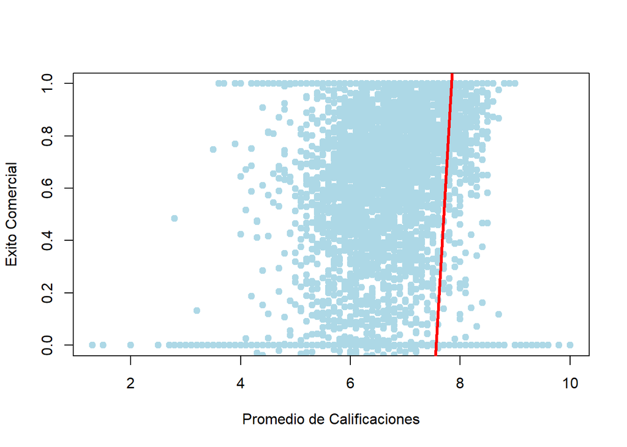

```r
movies <- read.csv("movies.csv", stringsAsFactors = FALSE)
# Reemplazar NA e Inf en 'revenue', 'budget', y 'voteAvg' por la mediana
movies$revenue[is.na(movies$revenue) | is.infinite(movies$revenue)] <- median(movies$revenue, na.rm = TRUE)
movies$budget[is.na(movies$budget) | is.infinite(movies$budget)] <- median(movies$budget, na.rm = TRUE)
movies$voteAvg[is.na(movies$voteAvg) | is.infinite(movies$voteAvg)] <- median(movies$voteAvg, na.rm = TRUE)

# Calcular las ganancias (gains)
movies$ganancia_neta <- ifelse(as.numeric(movies$revenue) == 0, 0,
                       (as.numeric(movies$revenue) - as.numeric(movies$budget)) / as.numeric(movies$revenue))


x <- movies$voteAvg
y <- movies$ganancia_neta
plot(x, y, pch = 19, col = "lightblue",
     xlab = "Promedio de Calificaciones",  # Título del eje X
     ylab = "Exito Comercial",
     ylim = c(0, max(y, na.rm = TRUE)))

# Agregar la línea de regresión
abline(lm(y ~ x), col = "red", lwd = 3)

text(paste("Correlación de Éxito comercial y Calificaciones:", round(cor(x, y), 2)), x = 25, y = 95)
```

#### Analisis Grafico

Este grafico nos muestra aquellos de 0 a 1 de ganancias. 1 es que generaron ganacias del 100% y 0% que su presupuesto no genero ganancias esto quiere decir que los ingresos apenas alcanzaron para cubrir los costes. Por otro lado tambien se clasifico como 0 aquellos que no solo no generaron ganancias sino que tampoco generaron ingresos. Cabe aclarar que aqui se colocan todos aquellos que tienen exito comercial (osea apartir de 0) , pues hay peliculas con ganancias negativas las cuales son fracasos que perdieron dinero, y por ende no se toman para el analisis.

Si quitamos las que no tuvieron ingresos ya que tambien son fracasos tendriamos esto

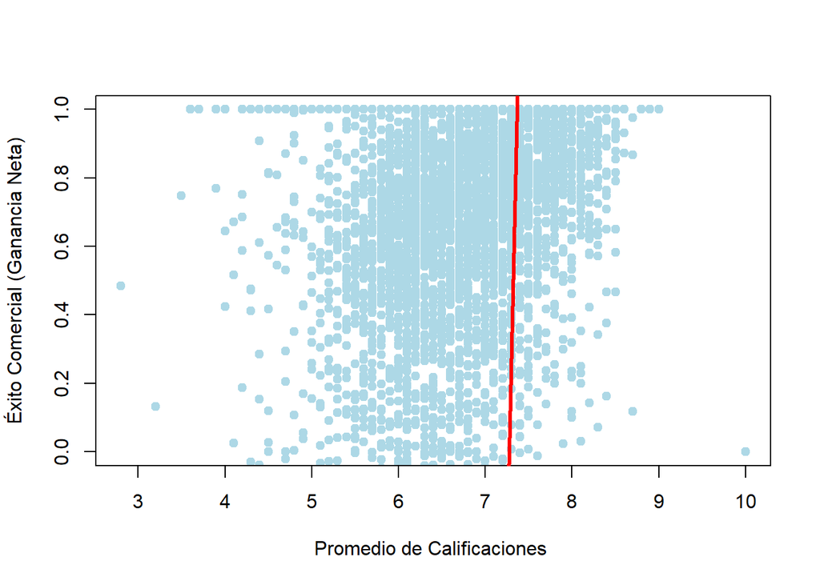

```r
movies <- read.csv("movies.csv", stringsAsFactors = FALSE)
# Reemplazar NA e Inf en 'revenue', 'budget', y 'voteAvg' por la mediana
movies$revenue[is.na(movies$revenue) | is.infinite(movies$revenue)] <- median(movies$revenue, na.rm = TRUE)
movies$budget[is.na(movies$budget) | is.infinite(movies$budget)] <- median(movies$budget, na.rm = TRUE)
movies$voteAvg[is.na(movies$voteAvg) | is.infinite(movies$voteAvg)] <- median(movies$voteAvg, na.rm = TRUE)

movies$gains <- (as.numeric(movies$revenue) - as.numeric(movies$budget)) / as.numeric(movies$revenue)

# Eliminar valores Inf o NA en 'gains'
movies <- movies[is.finite(movies$gains), ]

x <- movies$voteAvg
y <-  movies$gains
plot(x, y, pch = 19, col = "lightblue",
     xlab = "Promedio de Calificaciones ",  # Título del eje X
     ylab = "Éxito Comercial (Ganancia Neta)",
     ylim = c(0, max(y, na.rm = TRUE)))

# Agregar la línea de regresión
abline(lm(y ~ x), col = "red", lwd = 3)

text(paste("Correlación de Éxito comercial y Calificaciones:", round(cor(x, y), 2)), x = 25, y = 95)
```

#### Analisis Grafico

Existe relacion, tambien podemos observar que la mayoria en promedio es calificada con un 6, vemos que una parte importante de las peliculas que son calificadas por la critica por debajo del 6 tienen una ganancia neta del 100%. Lo que indica que su ingresos supero o triplico la ganancias de las peliculas. Aun asi hay muchas cintas que lograron tener muy buena critica y tener un exito comercial.

#### Conclusion

Como se puede observar el exito comercial y las calificaciones, sin embargo una gran cantidad de peliculas con un puntaje mayor a 6. Hay tenido una rendimiento muy alto en sus ganancias. Lo cual indica que las personas si desean pagar por ver una pelicula buena . Y de hecho este exito puede ser muy influenciado en la percepcion de lo buena que sea una cinta.

### 4.15 ¿Qué estrategias de marketing, como videos promocionales o páginas oficiales, generan mejores resultados?

Lo que haremos es comparar usando la ganancia entre las 2 estrategias.

### Marketing de Video

Si medimos sus ingresos veremos lo siguiente.

```r
# Lo primero que haremos es mapear
movies <- read.csv("movies.csv", stringsAsFactors = FALSE)


marketing <- movies %>%
  select(video, revenue)

# Ahora balanceamos
video_1 <- marketing %>% filter(video == TRUE)

# Seleccionar aleatoriamente 84 observaciones de video = 0 y de N/A
set.seed(123)  # Asegura reproducibilidad
video_0_sample <- marketing %>%
  filter(video == FALSE) %>%
  sample_n(84)

video_na_sample <- marketing %>%
  filter(is.na(video)) %>%
  sample_n(84)


# Unir ambos subconjuntos para tener balanceado el dataset
balanced_marketing <- bind_rows(video_1, video_0_sample, video_na_sample)

balanced_counts <- balanced_marketing %>%
  count(video)

print(balanced_counts)
```

```
##   video  n
## 1 FALSE 84
## 2  TRUE 84
## 3    NA 84
```

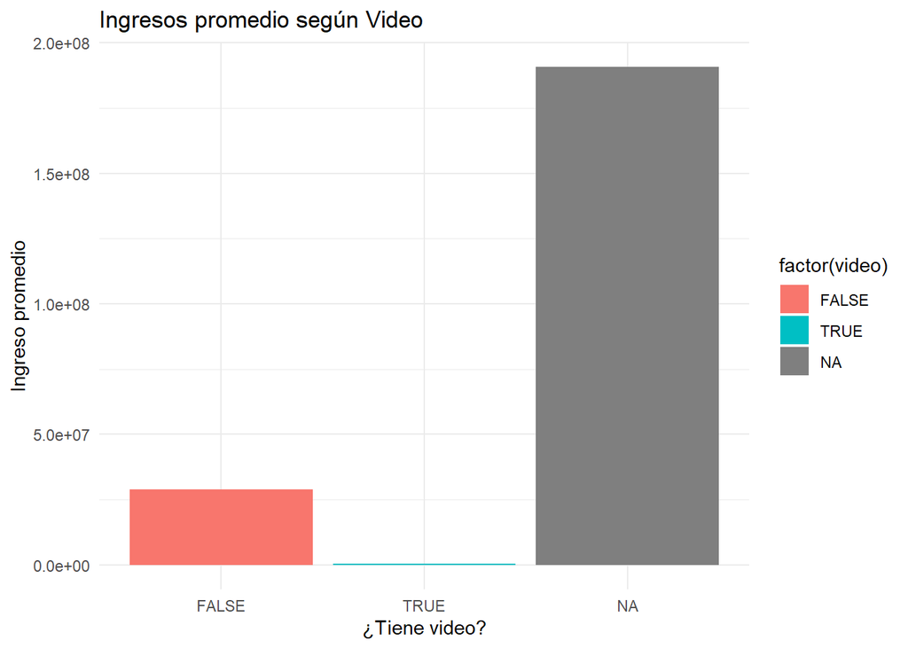

```r
balanced_marketing %>%
  group_by(video) %>%
  summarise(avg_revenue = mean(revenue, na.rm = TRUE)) %>%
  ggplot(aes(x = factor(video), y = avg_revenue, fill = factor(video))) +
  geom_col() +
  labs(title = "Ingresos promedio según Video",
       x = "¿Tiene video?",
       y = "Ingreso promedio") +
  theme_minimal()
```

#### Analisis Grafico

Lo que vemos aqui es el promedio de ingresos dependiendo si tiene video o no tiene. Por lo que se ve aqui es que no es concluyente por ende no se puede decir que tener o no video afecta a los ingresos percibidos. Pues tenemos demasiados valores que no conocemos si tienen o no video, por ende no se puede hacer una conclusion. Pero se puede ver que las que no tienen video tienen mayores ingresos.

Ahora si medimos su popularidad veremos lo siguiente

```r
# Lo primero que haremos es mapear
movies <- read.csv("movies.csv", stringsAsFactors = FALSE)


marketing <- movies %>%
  select(video, popularity)

# Ahora balanceamos
video_1 <- marketing %>% filter(video == TRUE)

# Seleccionar aleatoriamente 84 observaciones de video = 0 y de N/A
set.seed(123)  # Asegura reproducibilidad
video_0_sample <- marketing %>%
  filter(video == FALSE) %>%
  sample_n(84)

video_na_sample <- marketing %>%
  filter(is.na(video)) %>%
  sample_n(84)


# Unir ambos subconjuntos para tener balanceado el dataset
balanced_marketing <- bind_rows(video_1, video_0_sample, video_na_sample)

balanced_counts <- balanced_marketing %>%
  count(video)

print(balanced_counts)
```

```
##   video  n
## 1 FALSE 84
## 2  TRUE 84
## 3    NA 84
```

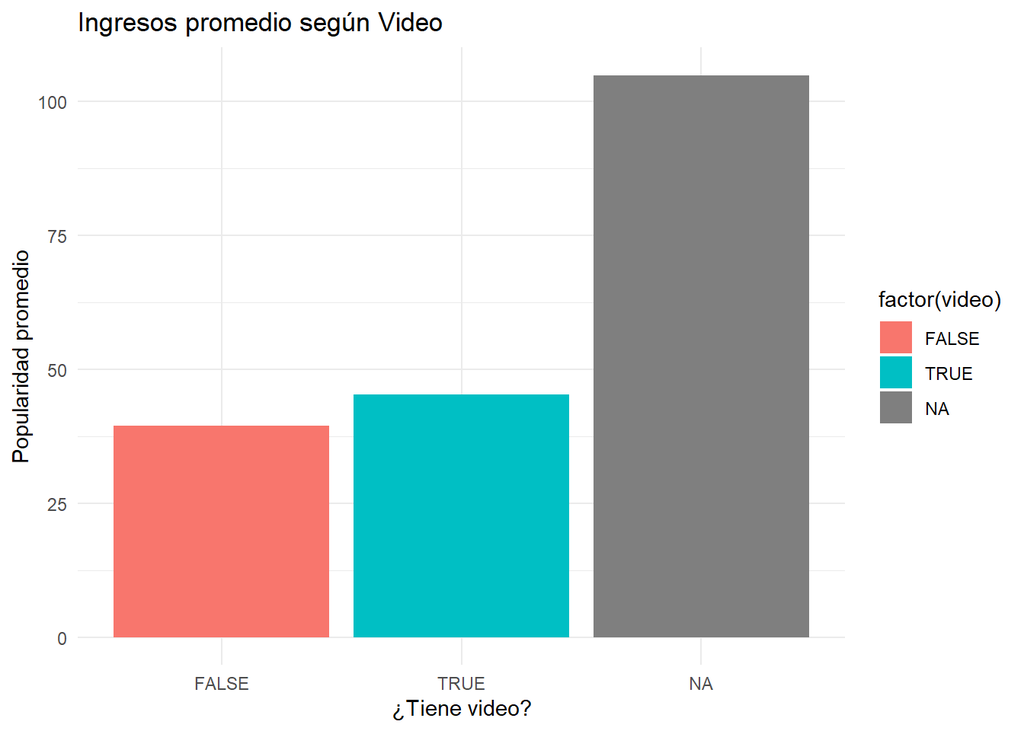

```r
balanced_marketing %>%
  group_by(video) %>%
  summarise(avg_popularity = mean(popularity, na.rm = TRUE)) %>%
  ggplot(aes(x = factor(video), y = avg_popularity, fill = factor(video))) +
  geom_col() +
  labs(title = "Ingresos promedio según Video",
       x = "¿Tiene video?",
       y = "Popularidad promedio") +
  theme_minimal()
```

### Marketing de Paginas Web

Si medimos los ingresos si tienen pagina , nos daria.

```r
movies <- read.csv("movies.csv", stringsAsFactors = FALSE)

#Primero mapeamos si tiene como un string que tenga y si no tiene como N/A

marketing <- movies %>%
  select(homePage, revenue) %>%
  mutate(homePage = ifelse(is.na(homePage), FALSE, TRUE))
homePage_counts <- marketing %>%
  count(homePage)

print(homePage_counts)
```

```
##   homePage    n
## 1    FALSE 5807
## 2     TRUE 4193
```

```r
#Ahora balanceamos
page_1 <- marketing %>% filter(homePage == TRUE)

set.seed(123)  # Asegura reproducibilidad
page_FALSE_sample <- marketing %>%
  filter(homePage == FALSE) %>%
  sample_n(4193)

balanced_marketing <- bind_rows(page_1,page_FALSE_sample)




balanced_counts <- balanced_marketing %>%
  count(homePage)

print(balanced_counts)
```

```
##   homePage    n
## 1    FALSE 4193
## 2     TRUE 4193
```

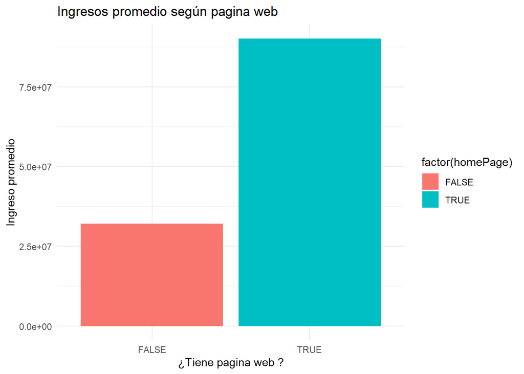

```r
#Ahora graficamos


balanced_marketing %>%
  group_by(homePage) %>%
  summarise(avg_revenue = mean(revenue, na.rm = TRUE)) %>%
  ggplot(aes(x = factor(homePage), y = avg_revenue, fill = factor(homePage))) +
  geom_col() +
  labs(title = "Ingresos promedio según pagina web",
       x = "¿Tiene pagina web ?",
       y = "Ingreso promedio") +
  theme_minimal()
```

#### Analisis Grafico

Si medimos la popularidad si tienen pagina , nos daria.

```r
movies <- read.csv("movies.csv", stringsAsFactors = FALSE)

#Primero mapeamos si tiene como un string que tenga y si no tiene como N/A

marketing <- movies %>%
  select(homePage, popularity) %>%
  mutate(homePage = ifelse(is.na(homePage), FALSE, TRUE))
homePage_counts <- marketing %>%
  count(homePage)

print(homePage_counts)
```

```
##   homePage    n
## 1    FALSE 5807
## 2     TRUE 4193
```

```r
#Ahora balanceamos
page_1 <- marketing %>% filter(homePage == TRUE)

set.seed(123)  # Asegura reproducibilidad
page_FALSE_sample <- marketing %>%
  filter(homePage == FALSE) %>%
  sample_n(4193)

balanced_marketing <- bind_rows(page_1,page_FALSE_sample)




balanced_counts <- balanced_marketing %>%
  count(homePage)

print(balanced_counts)
```

```
##   homePage    n
## 1    FALSE 4193
## 2     TRUE 4193
```

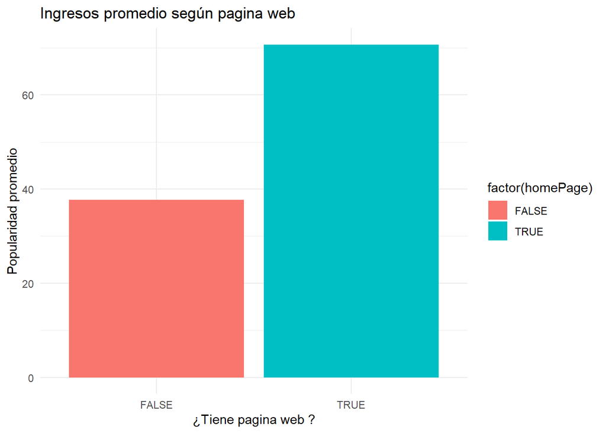

```r
#Ahora graficamos


balanced_marketing %>%
  group_by(homePage) %>%
  summarise(avg_popularity = mean(popularity, na.rm = TRUE)) %>%
  ggplot(aes(x = factor(homePage), y = avg_popularity, fill = factor(homePage))) +
  geom_col() +
  labs(title = "Ingresos promedio según pagina web",
       x = "¿Tiene pagina web ?",
       y = "Popularidad promedio") +
  theme_minimal()
```

#### Analisis Grafico

Podemos ver aqui que si llega a ser muy popular siguiendo la misma proporcion que los ingresos

#### Conclusion

Podemos ver que la mejor estrategia va a ser tener una pagina web, sin embargo se recomienda tambien tener un video , y colocarlo en las paginas web para poder apoyar a promocionar las peliculas, ya que el video si bien no rinde en ingresos si rinde en popularidad siendo mayor que no tenerlo .

### 4.16 ¿La popularidad del elenco está directamente correlacionada con el éxito de taquilla?

Para ello podemos hacer una grafica de correlacion.

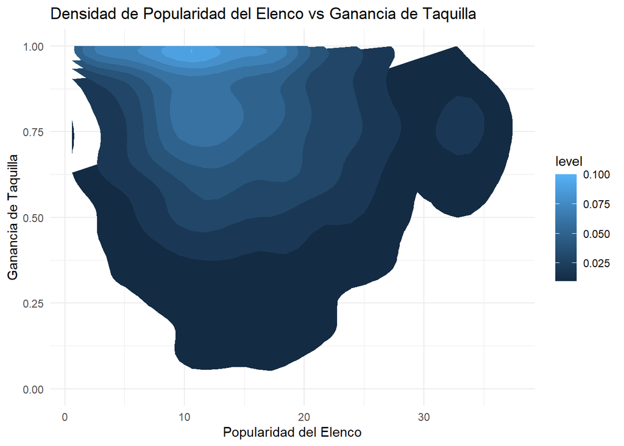

```r
# Leer el archivo CSV
movies <- read.csv("movies.csv", stringsAsFactors = FALSE)

# Seleccionar las columnas de interés
popularity <- movies %>%
  select(actorsPopularity, revenue, budget)

# Convertir los valores de actorsPopularity que están separados por "|" en un vector numérico

popularity$actorsPopularity <- sapply(popularity$actorsPopularity, function(x) {
  # Convertir la cadena separada por "|" en un vector numérico
  values <- as.numeric(unlist(strsplit(x, "\\|")))
  # Retornar el primer valor de la lista como ejemplo (o puedes hacer un promedio si lo prefieres)
  return(values[1])  # O usa mean(values) si quieres promediar los valores
})

# Calcular la ganancia de taquilla
popularity$ganancia <- (popularity$revenue - popularity$budget) / popularity$revenue

# Filtrar los valores que sean finitos para evitar NaN o infinitos
popularity <- popularity[is.finite(popularity$ganancia), ]



ggplot(popularity, aes(x = actorsPopularity, y = ganancia, fill = ..level..)) +
  stat_density_2d(geom = "polygon") +
  labs(title = "Densidad de Popularidad del Elenco vs Ganancia de Taquilla",
       x = "Popularidad del Elenco",
       y = "Ganancia de Taquilla") +
  ylim(0, max(popularity$ganancia, na.rm = TRUE)) +  # Limita Y de 0 al máximo
  theme_minimal()
```

#### Analisis Grafico

Como podemos ver este grafico la densidad de los actores estan dentro de una ganancia muy alta y una popularidad del elenco siendo entre 10 a 20. Por lo que se puede intuir en la grafica es que a mientras mas popularidad tenga un elenco puede exitir una mayor ganancia pero la mayoria de las peliculas suelen estar en el rango de una popularidad no tan alta y aun asi lograr exitos en la taquilla.

#### Conclusiones.

Si bien la popularidad influye en las ganancias de una pelicula que sean buenas, no significa que sea el unico factor, debido a que ha habido cintas con menor cantidad de actores populares que han logrado ser muy bien recibidas por el publico.

# 5 Genere usted otras seis preguntas que le parezcan interesantes.

### 5.1 ¿Cuál es la relación entre el presupuesto y la duración de las películas? ¿Las películas con mayor presupuesto tienden a ser más largas?

Para ello creamos una grafica de correlacion entre la duracion y el presupuesto.

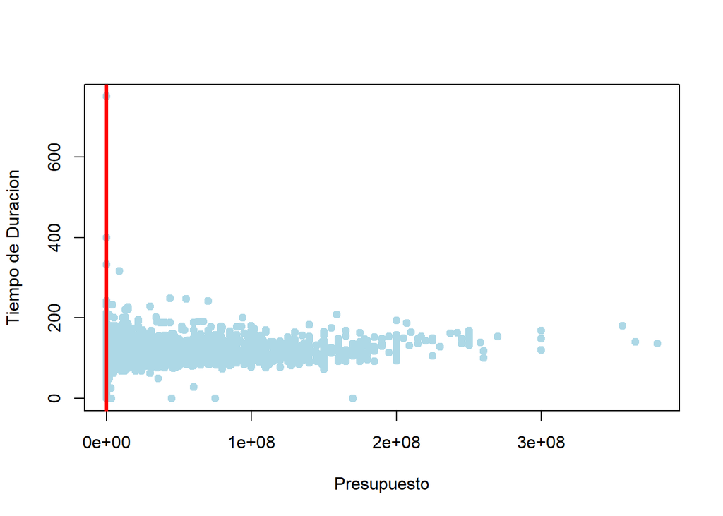

```r
movies <- read.csv("movies.csv", stringsAsFactors = FALSE)

plot(x= movies$budget, y = movies$runtime, pch = 19, col = "lightblue",
     xlab = "Presupuesto",  # Título del eje X
     ylab = "Tiempo de Duracion",
)

abline(lm(y ~ x), col = "red", lwd = 3)
```

#### Analisis grafico

Como se puede ver la mayoria de peliculas con un tiempo de duracion muy alto suelen tener un presupuesto muy bajo, casi siendo 0. Pero se nota una cierta tendencia a que las peliculas con mayor presupuesto su tiempo de duracion no sea tan largo. Al menos no mas de los 200 minutos.

#### Conclusion

Las peliculas con mayor presupuesto no tienden a ser mas largas al contrario siempre siguen la tendencia de durar menos de 200 minutos, la relacion entre estas 2 variables no es evidente.

### 5.2 ¿Las peliculas mas largas tienden a tener mayores ingresos?

Para ello realizamos otra grafica

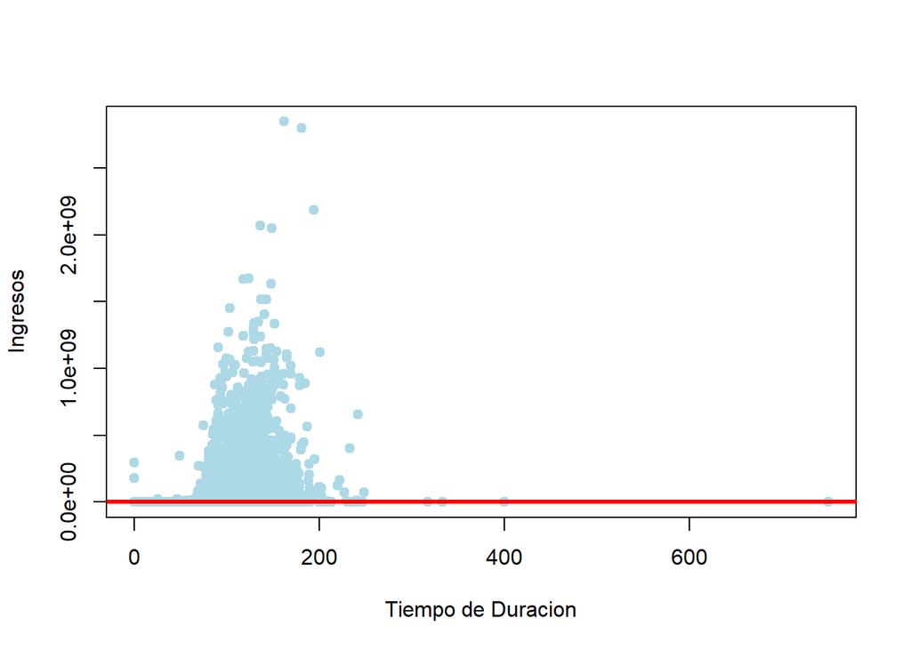

```r
movies <- read.csv("movies.csv", stringsAsFactors = FALSE)

plot(x= movies$runtime, y = movies$revenue, pch = 19, col = "lightblue",
     xlab = "Tiempo de Duracion",  # Título del eje X
     ylab = "Ingresos",
)

abline(lm(y ~ x), col = "red", lwd = 3)
```

#### Analisis Grafico

Como se puede ver las peliculas mas largas a los 50 minutos si alcanzan una gran cantidad de ingresos, pero tambien llega a un maximo y a partir de ahi mientras mas larga la pelicula menos ingresos genera

### 5.3 ¿Cómo ha evolucionado la cantidad de películas por género a lo largo de los años?

Calcularemos las peliculas por genero. Y las agruparemos por año

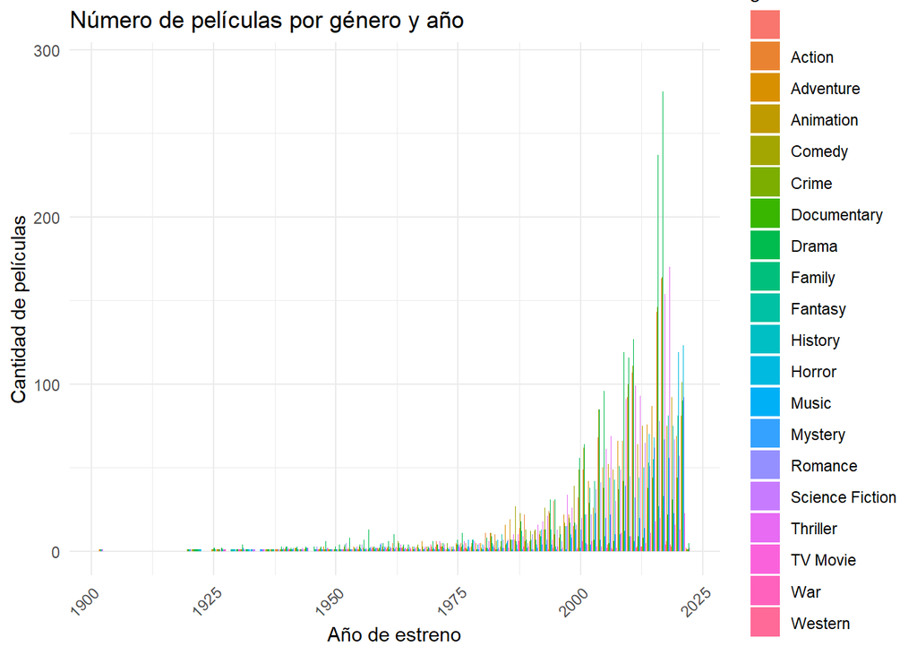

```r
movies <- read.csv("movies.csv", stringsAsFactors = FALSE)

movies$releaseYear <- as.numeric(substr(movies$releaseDate, 1, 4))


movies_por_anio <- movies %>%
  select(title,releaseYear, genres)

movies_por_anio <- movies_por_anio %>%
  separate_rows(genres, sep = "\\|") %>%  # Divide en varias filas
  group_by(genres, releaseYear) %>%      # Agrupa por género y año
  summarise(count = n(), .groups = "drop") # Cuenta las películas


ggplot(movies_por_anio, aes(x = releaseYear, y = count, fill = genres)) +
  geom_bar(stat = "identity", position = "dodge") +
  labs(title = "Número de películas por género y año",
       x = "Año de estreno",
       y = "Cantidad de películas") +
  theme_minimal() +
  theme(axis.text.x = element_text(angle = 45, hjust = 1))
```

### 5.4 ¿Cuales fueron los paises que se rodaron filmes con mayor rendimiento?

Calcularemos la ganancia generada y luego la contrastaremos en un grafico de barras con respecto a los paises.

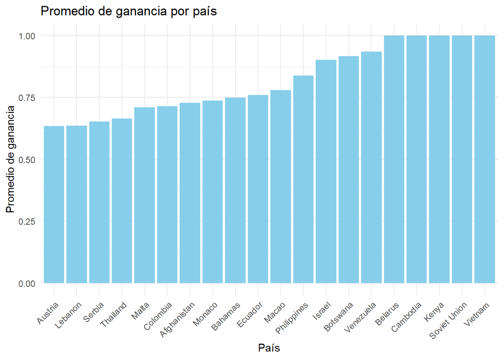

```r
movies_por_pais <- movies %>%
  select(title, revenue, budget,productionCountry)

# Calculamos la ganancia
movies_por_pais$ganancia <- (movies_por_pais$revenue - movies_por_pais$budget) / movies_por_pais$revenue

# Filtramos valores finitos
movies_por_pais <- movies_por_pais[is.finite(movies_por_pais$ganancia), ]


movies_por_pais <- movies_por_pais %>%
  separate_rows(productionCountry, sep = "\\|")


movies_por_pais_promedio <- movies_por_pais %>%
  group_by(productionCountry) %>%
  summarise(promedio_ganancia = mean(ganancia), .groups = "drop")

top_20_paises <- movies_por_pais_promedio %>%
  arrange(desc(promedio_ganancia)) %>%
  head(20)

# Crear gráfico
ggplot(top_20_paises, aes(x = reorder(productionCountry, promedio_ganancia), y = promedio_ganancia)) +
  geom_bar(stat = "identity", fill = "skyblue") +
  labs(title = "Promedio de ganancia por país",
       x = "País",
       y = "Promedio de ganancia") +
  theme_minimal() +
  theme(axis.text.x = element_text(angle = 45, hjust = 1))  # Rotar etiquetas del eje X
```

#### Conclusion

En conclusion si se desea un promedio de ganancias bueno es mejor filmar en estos paises, debido a que puede ser que los costos no se eleven tanto , y puede ayudar a generar peliculas que sean mas entretenidas y llamativas al publico al conocer lugares que no han visto.

### 5.5 ¿Cual son los actores que mas recaudacion ha tenido?

Para ello realizaremos una tabla

```r
# Seleccionamos las columnas relevantes
movies_por_actor <- movies %>%
  select(actors, revenue)

# Limpiamos posibles caracteres no estándar en los nombres de los actores
movies_por_actor$actors <- iconv(movies_por_actor$actors, from = "UTF-8", to = "ASCII//TRANSLIT")

# Separamos a los actores en filas
movies_por_actor <- movies_por_actor %>%
  separate_rows(actors, sep = "\\|")

# Calculamos el promedio de ingresos por actor
movies_por_actor_promedio <- movies_por_actor %>%
  group_by(actors) %>%
  summarise(promedio_ingresos = mean(revenue, na.rm = TRUE), .groups = "drop")

# Ordenamos y seleccionamos los 20 actores con mayor promedio de ingresos
top_20_actores <- movies_por_actor_promedio %>%
  arrange(desc(promedio_ingresos)) %>%
  head(20)

# Imprimir los primeros 20 actores

knitr::kable(top_20_actores, format= "html")
```

| actors | promedio_ingresos |
| --- | --- |
| David Van Horn | 2847246203 |
| James Patrick Pitt | 2847246203 |
| Jason Whyte | 2847246203 |
| Jon Curry | 2847246203 |
| Kyla Warren | 2847246203 |
| Kyle Dryberg | 2847246203 |
| Peter Dillon | 2847246203 |
| Sean Anthony Moran | 2847246203 |
| Sonia Yee | 2847246203 |
| Ameenah Kaplan | 2046239637 |
| Ethan Dizon | 2046239637 |
| Florence Kasumba | 2046239637 |
| Harrison Osterfield | 2046239637 |
| Laura Miller | 2046239637 |
| Letitia Wright | 2046239637 |
| Marie Mouroum | 2046239637 |
| Michael Anthony Rogers | 2046239637 |
| Michael James Shaw | 2046239637 |
| Olaniyan Thurmon | 2046239637 |
| Ross Marquand | 2046239637 |

#### Conclusion

Como se puede observar estos son los actores que mas ingresos si bien no han generado en promedio sus peliculas en las que han estado han tenido muchos ingresos. Ello puede servir para poder elegir que elenco de celebridades elegir para una nueva cinta.

### 5.6 ¿Que idiomas de las peliculas son los mas consumidos (con mayor ingresos)?

```r
movies_por_lengua <- movies %>%
  select(originalLanguage, revenue )


# Calculamos el promedio de ingresos por lengua
movies_por_lengua_promedio <- movies_por_lengua %>%
  group_by(originalLanguage) %>%
  summarise(promedio_ingresos = mean(revenue, na.rm = TRUE), .groups = "drop")


top_20_lenguas <- movies_por_lengua_promedio %>%
  arrange(desc(promedio_ingresos)) %>%
  head(20)


knitr::kable(top_20_lenguas, format= "html")
```

| originalLanguage | promedio_ingresos |
| --- | --- |
| zh | 74864948 |
| te | 73338967 |
| en | 69581771 |
| ar | 64978931 |
| hi | 26536670 |
| cn | 19017166 |
| ko | 13487526 |
| fr | 11139464 |
| fa | 10768392 |
| ja | 9509624 |
| sv | 9112728 |
| de | 6766426 |
| ru | 5990880 |
| it | 5091298 |
| nb | 4159678 |
| th | 3638706 |
| pt | 3383692 |
| tl | 3360000 |
| es | 3344984 |
| cs | 3319425 |